# An Examination of the Health and Economic Impact of Weather

## Synopsis

in the following analysis, we will examine a collection of weather event data from the US between the years of 1950 and 2011. Through this analysis we have attempted to address:

- What type of weather has the biggest health impact?
- What type of weather has the biggest economic impact?

Our findings show that Tornadoes appear to have the highest impact on population health, both in terms of injuries and fatalities. However, flooding and hurricanes appear to have the largest economic impact.

## Data Processing

The data used in this analysis is located at: [link](https://d396qusza40orc.cloudfront.net/repdata%2Fdata%2FStormData.csv.bz2)

We’ll download, unarchive, and read in the data to a variable called `stormData`:

```r
archiveFile <- "StormData.csv.bz2"
download.file("https://d396qusza40orc.cloudfront.net/repdata%2Fdata%2FStormData.csv.bz2", archiveFile)
rawStormData <- read.csv(archiveFile)
```

R makes some intelligent guesses about data types when reading in data, but we also need to do some housekeeping. Function definitions for `cleanStr`, `mapEVTYPE`, `getExp` are shown in Appendix 1.

```r
stormData <- rawStormData

# Convert BGN_DATE factor -> datetime
stormData$BGN_DATE <- date(mdy_hms(stormData$BGN_DATE))

# Convert END_DATE factor -> datetime
stormData$END_DATE <- date(mdy_hms(stormData$END_DATE))
# Fix missing END_DATE
# ASSUMPTIONS:
# Where END_DATE is not specified in the database, I make the assumption
# that the event does not last longer than 24 hours. In essence, I assign
# END_DATE = BGN_DATE
stormData$END_DATE[is.na(stormData$END_DATE)] <-
  stormData$BGN_DATE[is.na(stormData$END_DATE)]

# Clean EVTYPE
stormData$EVTYPE <- unlist(lapply(stormData$EVTYPE, cleanStr))
stormData$EVTYPE <- factor(mapEVTYPE(stormData$EVTYPE))

# Clean PROPDMG
stormData$PROPDMGEXP <- unlist(lapply(stormData$PROPDMGEXP, cleanStr))
stormData$PROPDMGEXPN <- getExp(stormData$PROPDMGEXP)
stormData$PROPDMG <- stormData$PROPDMG * stormData$PROPDMGEXPN

# Clean CROPDMG
stormData$CROPDMGEXP <- unlist(lapply(stormData$CROPDMGEXP, cleanStr))
stormData$CROPDMGEXPN <- getExp(stormData$CROPDMGEXP)
stormData$CROPDMG <- stormData$CROPDMG * stormData$CROPDMGEXPN

# Create TOTALDMG
stormData$TOTALDMG <- stormData$CROPDMG + stormData$PROPDMG

# Remove unused columns
usedCols = c("BGN_DATE", "TIME_ZONE", "STATE", "EVTYPE", "END_DATE",
             "LENGTH", "WIDTH", "F", "MAG", "FATALITIES", "INJURIES",
             "PROPDMG", "CROPDMG", "TOTALDMG")
newStormData <- stormData[, usedCols]
```

The code shown above does the following:

- Dates (`BGN_DATE`, `END_DATE`) are converted from factors into datetime instances
  - `NA` values are handled in `END_DATE` by assuming the event lasts less than 24 hours
- Event types are cleaned up into predefined categories
  - Not all events are cleaned, but the majority fit into fixed categories
  - Category names are as defined in the database documentation [here](https://www.ncdc.noaa.gov/stormevents/pd01016005curr.pdf)
- Economic costs are cleaned and simplified
  - `CROPDMGEXP` and `PROPDMGEXP` are converted from character values into powers of ten
  - `CROPDMG` and `PROPDMG` are scaled by the appropriate powers of ten above
- `TOTALDMG` with the sum of `CROPDMG` and `PROPDMG` is created
- A simplified version of the database is created with a subset of columns to be analyzed

Some columns were removed due to redundancy (e.g. `CROPDMGEXP`), while others were removed due to limited usefulness (e.g. `REMARKS`)

## Results

By quantitative analysis of the NOAA dataset, we will attempt evaluate the following:

- Which types of weather events are most harmful to the health of the US population?
- Which types of events have the greates economic consequences?

### Event Health Impact

The NOAA dataset contains two different metrics by which we can measure impact to population health: fatalities and injuries. While fatalities are certainly a devastating impact of some weather events, they do not necessarily tell the whole story. The additional healthcare expense of treating injuries of people affected by weather events can translate to a heavier economic burden in a local area. For this reason, we evaluate weather event severity based on both metrics.

There are many metrics we could use to evaluate the relative fatality and injury counts of weather events. For our analysis, we chose to use maximum fatalities/injuries from a single event (severity) and total fatalities/injuries between 1950-2011 (frequency). These two summaries of the data may give local officials the best idea where investments can be made to safeguard the population.

#### Figure 1: Top Ten Weather Event Types by Fatalities

```r
library(dplyr)
library(pander)

topFatalities <- stormData %>%
  group_by(EVTYPE) %>%
  summarize(total_fatalities = sum(FATALITIES, na.rm=TRUE),
            max_fatalities = max(FATALITIES, na.rm=TRUE)) %>%
  filter(total_fatalities>0) %>%
  arrange(desc(total_fatalities), desc(max_fatalities)) %>%
  mutate("Rank"=row_number()) %>%
  top_n(n = 10, wt = total_fatalities) %>%
  rename("Fatalities due to Single Event" = max_fatalities, "Total Fatalities 1950-2011" = total_fatalities, "Event Type" = EVTYPE)
pander(topFatalities)
```

| Event Type | Total Fatalities 1950-2011 | Fatalities due to Single Event | Rank |
| --- | --- | --- | --- |
| TORNADO | 5633 | 158 | 1 |
| EXCESS HEAT | 3132 | 583 | 2 |
| FLASH FLOOD | 1035 | 20 | 3 |
| LIGHTNING | 817 | 5 | 4 |
| THUNDERSTORM | 726 | 11 | 5 |
| FLOOD | 490 | 15 | 6 |
| STRONG WIND | 419 | 8 | 7 |
| RIP CURRENT | 368 | 6 | 8 |
| WINTER STORM | 279 | 10 | 9 |
| WIND CHILL | 237 | 10 | 10 |

#### Figure 2: Top Ten Weather Event Types by Injuries

```r
topInjuries <- stormData %>%
  group_by(EVTYPE) %>%
  summarize(total_injuries = sum(INJURIES, na.rm=TRUE),
            max_injuries = max(INJURIES, na.rm=TRUE)) %>%
  filter(total_injuries>0) %>%
  arrange(desc(total_injuries), desc(max_injuries)) %>%
  mutate("Rank"=row_number()) %>%
  top_n(n = 10, wt = total_injuries) %>%
  rename("Injuries due to Single Event" = max_injuries, "Total Injuries 1950-2011" = total_injuries, "Event Type" = EVTYPE)
pander(topInjuries)
```

| Event Type | Total Injuries 1950-2011 | Injuries due to Single Event | Rank |
| --- | --- | --- | --- |
| TORNADO | 91364 | 1700 | 1 |
| THUNDERSTORM | 9449 | 70 | 2 |
| EXCESS HEAT | 9209 | 519 | 3 |
| FLOOD | 6802 | 800 | 4 |
| LIGHTNING | 5231 | 51 | 5 |
| ICE STORM | 2154 | 1568 | 6 |
| WINTER STORM | 1968 | 165 | 7 |
| STRONG WIND | 1830 | 89 | 8 |
| FLASH FLOOD | 1802 | 150 | 9 |
| WILDFIRE | 1606 | 150 | 10 |

In conclusion, we can see that by both metrics, Tornadoes appear to be most impactful in terms of total numbers over a sixty year period. It is interesting to note, however, that the highest number of fatalities due to a single event is attributed to excess heat.

### Event Economic Impact

We can examine the economic impact of weather events using a similar strategy.

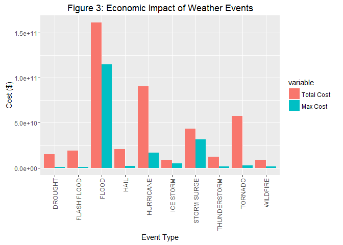

```r
library(ggplot2)
library(dplyr)
library(reshape2)

topEconEvents <- stormData %>%
  group_by(EVTYPE) %>%
  summarize(total_cost = sum(TOTALDMG, na.rm=TRUE),
            max_cost = max(TOTALDMG, na.rm=TRUE)) %>%
  filter(total_cost>0) %>%
  top_n(n = 10, wt = total_cost) %>%
  rename("Total Cost" = total_cost, "Max Cost" = max_cost)

topEconEvents.long <- melt(topEconEvents, id.vars="EVTYPE")
topEconEvents.long$EVTYPE <- factor(topEconEvents.long$EVTYPE)
topEconEvents.long$variable <- factor(topEconEvents.long$variable)

plt <- ggplot(topEconEvents.long, aes(x=EVTYPE, y=value, fill=variable)) +
  geom_bar(stat="identity", position="dodge") +
  scale_color_discrete("Metric") +
  xlab("Event Type") +
  ylab("Cost ($)") +
  ggtitle("Figure 3: Economic Impact of Weather Events") +
  theme(axis.text.x=element_text(angle=90, hjust=1, vjust=0.5))
plt
```

There are a few observations that can be drawn from this plot. First, we note that flooding appears to have, by far, the most significant economic impact. However, we also note that a significant portion of this total cost is attributed to a single event. Although hurricanes fall far short of the total cost, the maximum cost of a single event is far lower. This would suggest hurricanes occur with much higher frequency and may add up to a larger number over time.

## Appendix 1

```r
library(lubridate)

# Utility function for cleaning strings
#
cleanStr <- function(s) {
  s <- gsub("^\\s+|\\s+$", "", s)
  s <- gsub("[[:punct:]]", " ", s)
  toupper(s)
}


# Utility function for cleaning EVTYPE
#
# ASSUMPTIONS:
# The data input into this column is highly irregular and does not
# conform to a particular set of valid entries. I have attempted to
# standardize the names as much as possible. There are still a large
# number of entries with unique values that have not been addressed.
# In addition, it is possible that some events have multiple types
# in the description. I make no assumption about "importance" when
# assigning the single category to an event. Names are filtered
# roughly alphabetically using `grep`, and secondary event types
# are most likely removed.
#
mapEVTYPE <- function(v) {
  v[grep("ASTRO.+LOW", v)] <- "ASTRONOMICAL LOW TIDE"
  v[grep("ASTRO.+HIGH", v)] <- "ASTRONOMICAL HIGH TIDE"
  v[grep("AVAL", v)] <- "AVALANCHE"
  v[grep("BLIZ", v)] <- "BLIZZARD"
  v[grep("COAST.+FLOOD", v)] <- "COASTAL FLOOD"
  v[grep("CHILL", v)] <- "WIND CHILL"
  v[grep("DENSE.+FOG", v)] <- "DENSE FOG"
  v[grep("SMOKE", v)] <- "SMOKE"
  v[grep("DROUG", v)] <- "DROUGHT"
  v[grep("DEV[IE]L", v)] <- "DUST DEVIL"
  v[grep("DUST *ST", v)] <- "DUST STORM"
  v[grep("SAHARA", v)] <- "DUST STORM"
  v[grep("EXCESS.+HEAT", v)] <- "EXCESS HEAT"
  v[grep("EXTR.+COLD", v)] <- "EXTREME COLD"
  v[grep("FLASH", v)] <- "FLASH FLOOD"
  v[setdiff(grep("FLOOD", v), grep("FLASH", v))] <- "FLOOD"
  v[grep("FRE.+FOG", v)] <- "FREEZING FOG"
  v[grep("FROS", v)] <- "FROST/FREEZE"
  v[grep("FUN", v)] <- "FUNNEL CLOUD"
  v[grep("HAIL", v)] <- "HAIL"
  v[grep("HEAT", v)] <- "EXCESS HEAT"
  v[grep("HEAV.+(RAIN|PREC)", v)] <- "HEAVY RAIN"
  v[grep("HEAV.+SNOW", v)] <- "HEAVY SNOW"
  v[grep("SURF", v)] <- "HEAVY SURF"
  v[grep("HURR", v)] <- "HURRICANE"
  v[grep("ICE", v)] <- "ICE STORM"
  v[grep("SLEE", v)] <- "SLEET"
  v[grep("THUNDER", v)] <- "THUNDERSTORM"
  v[grep("TSTM", v)] <- "THUNDERSTORM"
  v[grep("WATERSPOUT", v)] <- "WATERSPOUT"
  v[grep("TORN", v)] <- "TORNADO"
  v[grep("DEPR", v)] <- "TROPICAL DEPRESSION"
  v[grep("TROP.+STORM", v)] <- "TROPICAL STORM"
  v[grep("TSU", v)] <- "TSUNAMI"
  v[grep("VOL.+ASH", v)] <- "VOLCANIC ASH"
  v[grep("WILD", v)] <- "WILDFIRE"
  v[grep("WINT", v)] <- "WINTER STORM"
  v[grep("LIGHTN", v)] <- "LIGHTNING"
  v[grep("HIGH.+WIND", v)] <- "STRONG WIND"
  v[grep("STRONG", v)] <- "STRONG WIND"
  v[grep("SUMMARY", v)] <- NA
  return(v)
}


# Function for extracting exponent for PROPDMG and CROPDMG
#
# ASSUMPTIONS:
# There are both numeric and character values in the
# PROPDMGEXP and CROPDMGEXP variables. For numeric values,
# I have assumed that this is a power of ten multiplying
# PROPDMG or CROPDMG. For character values, I have assumed
# this variable refers to a particular power of ten
# (e.g. "M" -> Million -> $1,000,000 x PROPDMG).
# Where the value does not fit either of these criteria,
# I ignore the value of this variable (i.e, exponent = 1)
#
getExp <- function(v) {
  v[grep("0", v)] <- "1"
  v[grep("1", v)] <- "10"
  v[grep("[2H]", v)] <- "100"
  v[grep("[3K]", v)] <- "1000"
  v[grep("4", v)] <- "10000"
  v[grep("5", v)] <- "100000"
  v[grep("[6M]", v)] <- "1000000"
  v[grep("7", v)] <- "10000000"
  v[grep("8", v)] <- "100000000"
  v[grep("[9B]", v)] <- "1000000000"
  v <- as.numeric(v)
  v[is.na(v)] <- 1
  return(v)
}
```